# Relatório 02 - Como usar o projeto Relatórios

Ben Dêivide

29/04/2022

# 1 Objetivo

Descrever como realizar o projeto relatórios com detalhamento.

# 2 Apresentação do relatório

Diante do objetivo do relatório, será apresentado nas próximas subseções, os pontos a serem discutidos.

## 2.1 Pacotes necessários

Como já aludido no [Relatório 1](https://mac8320.github.io/rel01/index.html), o pacote em R é um diretório de arquivos necessários para carregar um código de funções, dados, documentações de ajuda, testes, etc. Sendo assim, será preciso instalar alguns pacotes para a realização do projeto, são eles:

- `rmarkdown`: formato de arquivo que permite a criação de documentos dinâmicos utilizando R.
- `postcard`: coleção de modelos R Markdown para criar sites de página única simples e fáceis de personalizar.
- `knitr`: mecanismo para geração de relatórios dinâmicos com R. É um pacote na linguagem de programação R que permite a integração do código R em documentos LaTeX, LyX, HTML, Markdown, AsciiDoc e reStructuredText.
- `tinytex`: distribuição personalizada do LaTeX baseada no TeX Live, utilizado para criar documentos PDF a partir do R Markdown.

## 2.2 Conceitos básicos sobre o RMarkdown

### 2.2.1 Markdown

Segundo seu prórprio criador, John Gruber em 2004, podemos defini-lo como:

*Markdown é uma ferramenta de conversão de texto para HTML para escritores da web. O Markdown permite que você escreva usando um formato de texto simples fácil de ler e escrever e, em seguida, converta-o em XHTML (ou HTML) estruturalmente válido.*

Sendo assim, ele se trata de uma linguagem de marcação simplificada, criada para que o autor foque no texto e não na formatação. Além disso, o R Markdown pode ser convertido para Markdown através do knitr.

### 2.2.2 Sintaxe do Markdown

A sintaxe do Markdown é muito simples, e pode ser resumida da seguinte forma:

- Seções:

```r
# Título
## Sub-título
### Sub-sub-título
```

# Título

## Sub-título

### Sub-sub-título

- Para escrever em itálico: (`*itálico*`) *itálico*
- Para escrever em negrito: (`**negrito** ou __negrito__`) **negrito** ou **negrito**
- Nota de rodapé: (`Marco Antônio^[Estudante de Engenharia Civil]`) Marco Antônio[^1]
- Link: `[Nome do link](link)` [Site do professor](https://bendeivide.github.io)
- Inserir imagens: `![Nome da imagem](local da imagem){width="tamanho da imagem em %"}`:

- Inserindo resultado de código no corpo do texto : 5.5
  - Exemplo: Tendo um conjunto de dados a seguir:

```r
dado <- rnorm(100);

dado
```

```
##   [1] -1.08724238  0.13444483  0.92743874 -1.79937817  3.16797536 -0.34009409
##   [7] -0.57656168  0.55931928 -0.49244640 -0.14095057  0.37248015 -0.02308217
##  [13] -0.07705772 -0.77389655  0.69219807 -0.78422708 -0.76077324 -1.71723723
##  [19] -0.27705704 -0.08944964  0.60763470 -0.87696591  1.07950535 -0.88083105
##  [25]  0.12552003 -1.71972994  0.37311198  0.09334309 -0.55922206 -0.26206967
##  [31] -0.90780103 -1.62650822 -0.25884686 -0.08517938  0.29777074 -0.57890004
##  [37] -1.40370844  0.84079876  1.10651961 -1.83952831  0.03494679 -0.12296993
##  [43]  0.65325004 -0.24320834 -0.04657172  0.92809935  0.10559006  0.59696513
##  [49] -0.84925917 -1.36606595 -0.93296533  2.02024223 -0.31493164  0.66665422
##  [55] -1.31884859 -0.31485039  0.11105138  0.10502841  1.35932789  1.37852772
##  [61] -0.32340561 -0.56209326 -0.90448800 -0.43706919  0.53885213  0.58320708
##  [67]  2.33831655 -0.14387765  0.86884993  0.77492687  0.05046052 -1.93430412
##  [73] -0.35022575 -0.52502148  0.21324555  0.91011696  1.33751055 -0.78775314
##  [79] -0.48099206  1.31223075  0.88866102  0.02995874 -2.01526831 -0.87222061
##  [85]  1.57152998 -0.50299509 -0.78038902 -0.54185277 -0.04594983 -0.13248430
##  [91] -1.08352997 -0.99400108  0.18208919  0.70944574 -0.92813860  0.99008339
##  [97] -1.69444276 -1.14135561  0.93107165 -1.08222295
```

A média desses valores é: -0.111442, e o desvio padrão é 0.964629, bem como a variância dada por: 0.9305091.

- Mostrando apenas o código:

```r
# Como importar dados

dado <- read.table(file, header, sep, dec)
```

## 2.3 Utilizando o GitHub

o GitHub é um serviço baseado em nuvem que hospeda um sistema de controle de versão (VCS) chamado Git. Ele permite que os desenvolvedores colaborem e façam mudanças em projetos compartilhados enquanto mantêm um registro detalhado do seu progresso. Sua interface pode ser visualizada na **Figura 1**.

[figure not shown]

Figura 1 - Interface do GitHub

### 2.3.1 Instalação do Git

Para a utilização da plataforma, você deve ter o Git instalado no seu computador. Para instala-lo, basta clicar no seguinte link: [Download do Git](https://git-scm.com/downloads). A **Figura 2** reprenta a página para o download.

[figure not shown]

Figura 2 - Site para download do Git

O programa é compatível com os seguintes sistemas operacionais: macOS, Windows e Linux/Unix.

### 2.3.2 Criando o registro no GitHub

Feito o Download e tendo instalado o Git, você deve se registrar na plataforma, através do link: [Registro](https://github.com/signup?source=login).

## 2.4 Vinculando o R ao GitHub

Para vincular-mos o R do Rstudio ao GitHub é necessário a criação de um repositório pra sincronização dos projetos. Assim, você deve fazer o loguin em sua conta do GitHub, clicar no botão + e em novo repositório, como representado na **Figura 3**.

[figure not shown]

Figura 3 - Criando um novo repositório

Em seguida, devemos nomea-lo, como indicado na **Figura 4**, selecionando também as opções *Public* e *Add a README file*.

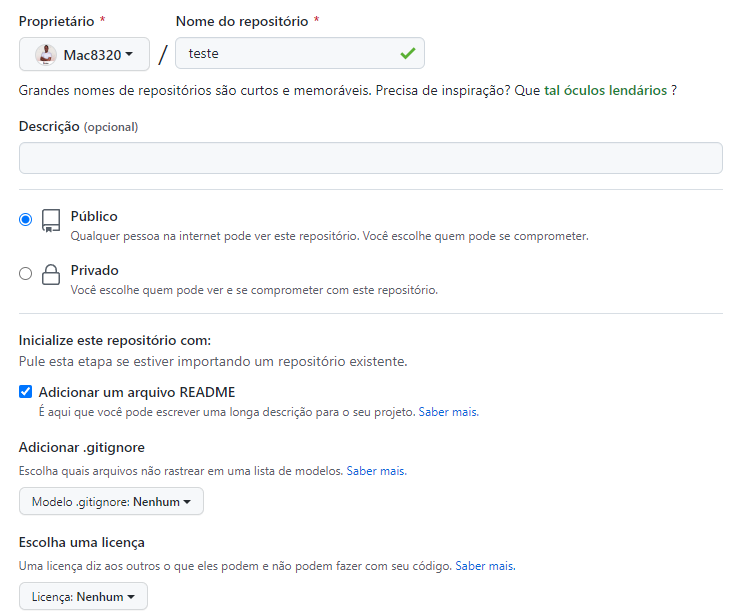

Figura 4 - Nomeando o repositório

Feito isso, clique na opção code e copie o link que se encontra na aba HTTPS, como indicado na **Figura 5**.

[figure not shown]

Figura 5 - Copiando o código do repositório

Abra o seu RStudio e siga o seguinte trajeto:

*File > New Project > Version Control > Git*

Feito isso, você será direcionado para o local representado na **Figura 6**. Cole o link na aba Repository URL e escolha um local na sua memória para armazená-lo.

[figure not shown]

Figura 6 - Clonando o repositório

Finalizada essa etapa, seu Rstudio estará sincronizado com o repositório do GitHub, como indicado na **Figura 7**.

[figure not shown]

Figura 7 - Repositório sincronizado

## 2.5 Enviando arquivos do RStudio para o GitHub

### 2.5.1 Utilizando a aba Git

O processo para enviar arquivos do RStudio para o GitHub consiste em 3 passos básicos, são eles: Adicionar localmente, comentar as alterações e enviar as alterações ao repositório GitHub.

Quando você está trabalhando com algum arquivo dentro do repositório clonado, na janela do terceiro quadrante é abilitada uma nova aba denominada *Git*. Sendo assim, para exportar esses arquivos para o GitHub, você deve primeiramente seleciona-los e clicar na opção commit, como pode ser visto na **Figura 8**.

[figure not shown]

Figura 8 - Aba Git

[figure not shown]

Figura 9 - Comentando

Após essa etapa, basta clicar no botão Push, que os arquivos serão direcionados para o GitHub. Para verificar se o processedimento foi bem sucedido, basta ir até o diretório que foi clonado dentro dentro do GitHub e procurar se os arquivos estão armazenados lá dentro, como mostra a **Figura 10**.

[figure not shown]

Figura 10 - Verificando o repositório

### 2.5.2 Utilizando o terminal

Uma outra forma de enviar arquivos do RStudio para o GitHub é através do terminal. Para isso, basta clicar na aba teminal que aparece no terceiro quadrante e realizar o seguinte processo:

```
$ git add .

$ git commit -m "Início do comentario"

$ git push -u origin master
```

## 2.6 Visualizando o projeto na web

Como já aludido, dentro do diretório onde o projeto foi salvo é criado uma série de documentos. Sendo assim, para fazer com o projeto seja exibido na web é preciso identificar um arquivo extensão *.html* e verificar se seu nome está com index. Esse é um procedimento padrão, ou seja, o nome do arquivo deve ser sempre assim.

Em seguida, no RStudio, clique na setinha que aparece ao lado do botão Knit no seu arquivo RMardown e selecione a opção Knit to HTML.

Por fim, basta ir até o seu repositório no GitHub, clicar em *Settings* e em seguida na opção *pages*. Feito isso, defina a fonte como main root e salve.

[^1]: Estudante de Engenharia Civil